# Assignment_1

Group 7

2/28/2020

- Question:

1- the optimal price for selling the car seats at those stores where the shelve location is good (i.e. the product is highly visible)? 2- the optimal price for selling the car seats at those stores where the shelve location is bad (i.e. the product is highly visible)? Cost of producing each car seat is $55.0 1- Plot the optimal price for selling the car seats at those stores where the shelve location is good and those where the shelve location is bad when varying the production costs from $40 to $85.

- Solution:

```r
library(ISLR)
library(dplyr)
library(gridExtra)
```

```r
library(ggplot2)
SafeBabies <- Carseats %>% select("Sales", "Price", "ShelveLoc")
```

- Flitering the data:

```r
Good <- filter(SafeBabies,ShelveLoc == 'Good')
Med <- filter(SafeBabies,ShelveLoc == 'Medium')
Bad <- filter(SafeBabies,ShelveLoc == 'Bad')
```

- Regression Model for Sales w.r.t price for car seats where the shelve location is good :

```r
Shelf_Good<-Good[order(Good$Price),]
head(Shelf_Good)
```

```
##    Sales Price ShelveLoc
## 80 14.37    53      Good
## 52 12.98    63      Good
## 8  13.91    68      Good
## 64 15.63    72      Good
## 56 11.82    74      Good
## 37 11.48    77      Good
```

```r
Model_Good <- lm(Shelf_Good$Sales ~ Shelf_Good$Price, data = Shelf_Good)
summary(Model_Good)
```

```
##
## Call:
## lm(formula = Shelf_Good$Sales ~ Shelf_Good$Price, data = Shelf_Good)
##
## Residuals:
##    Min     1Q Median     3Q    Max
## -3.721 -1.351 -0.098  1.483  4.353
##
## Coefficients:
##                   Estimate Std. Error t value Pr(>|t|)
## (Intercept)      17.968864   0.988008  18.187  < 2e-16 ***
## Shelf_Good$Price -0.065785   0.008199  -8.023 5.85e-12 ***
## ---
## Signif. codes:  0 '***' 0.001 '**' 0.01 '*' 0.05 '.' 0.1 ' ' 1
##
## Residual standard error: 1.888 on 83 degrees of freedom
## Multiple R-squared:  0.4368, Adjusted R-squared:   0.43
## F-statistic: 64.37 on 1 and 83 DF,  p-value: 5.848e-12
```

- The equation for optimal price for car seats where shelve location is good:

```r
Good_optimal_price = (-0.065785 *55 - 17.968864)/(2 * -0.065785)
Good_optimal_price
```

```
## [1] 164.0727
```

- Optimal price for change in production cost from 40$ to 85$:

```r
result_Good <- vector("numeric", 40)
for(cost in 40:86) {
     Good_Optimised_results <- (-0.065785 *cost - 17.968864)/(2 * -0.065785)
   result_Good[cost - 40] <- Good_Optimised_results
}
head(result_Good)
```

```
## [1] 157.0727 157.5727 158.0727 158.5727 159.0727 159.5727
```

- Comparison of optimized price and change in cost:

```r
price<- c(40:85)
Good_Optimised_price<-cbind.data.frame(result_Good,price)
names(Good_Optimised_price)<-c('Optimized Price','Change in Cost')
```

- Regression Model for Sales w.r.t price for car seats where the shelve location is bad:

```r
Shelf_Bad<-Bad[order(Bad$Price),]
head(Shelf_Bad)
```

```
##    Sales Price ShelveLoc
## 51  7.78    64       Bad
## 40  9.32    70       Bad
## 3  10.81    72       Bad
## 71  6.88    72       Bad
## 92  8.14    78       Bad
## 23  8.01    79       Bad
```

```r
Model_Bad <- lm(Shelf_Bad$Sales ~ Shelf_Bad$Price, data = Shelf_Bad)
summary(Model_Bad)
```

```
##
## Call:
## lm(formula = Shelf_Bad$Sales ~ Shelf_Bad$Price, data = Shelf_Bad)
##
## Residuals:
##     Min      1Q  Median      3Q     Max
## -4.4622 -1.0617 -0.2014  1.2050  4.6412
##
## Coefficients:
##                  Estimate Std. Error t value Pr(>|t|)
## (Intercept)     11.832984   0.990317  11.949  < 2e-16 ***
## Shelf_Bad$Price -0.055220   0.008486  -6.507  3.7e-09 ***
## ---
## Signif. codes:  0 '***' 0.001 '**' 0.01 '*' 0.05 '.' 0.1 ' ' 1
##
## Residual standard error: 1.967 on 94 degrees of freedom
## Multiple R-squared:  0.3105, Adjusted R-squared:  0.3032
## F-statistic: 42.34 on 1 and 94 DF,  p-value: 3.702e-09
```

- The equation for optimal price for car seats where shelve location is bad:

```r
Bad_optimal_price = (-0.05522 * 55 - 11.832984) / (2 * -0.05522)
Bad_optimal_price
```

```
## [1] 134.644
```

- Optimal price for change in production cost from 40$ to 85$:

```r
result_Bad <- vector("numeric", 40)
for(cost in 40:86) {
     Bad_optimal_price <- (-0.05522 *cost - 11.832984)/(2 * -0.05522)
   result_Bad[cost - 40] <- Bad_optimal_price
}
head(result_Bad)
```

```
## [1] 127.644 128.144 128.644 129.144 129.644 130.144
```

- Comparison of optimized price and change in cost:

```r
price<- c(40:85)
Bad_Optimised_price<-cbind.data.frame(result_Bad,price)
names(Bad_Optimised_price)<-c('Optimized Price','Change in Cost')
```

- Plotting the optimal price for selling the car seats at those stores where the shelve location is good and bad:

```r
a<-ggplot(Good_Optimised_price, aes(Good_Optimised_price$`Optimized Price`, Good_Optimised_price$`Change in Cost`, colour='Good location')  ) + labs(title = 'Optimized Price VS Cost Price',x='Optimized price',y='Cost Price') + geom_line() +  scale_color_manual("", values = ("Good Price'" = "blue")) +geom_point(colour='black')
```

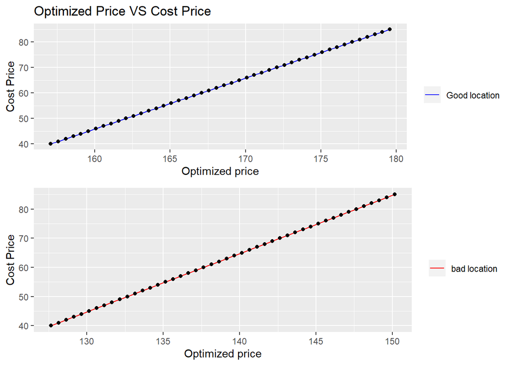

```r
b<-ggplot(Bad_Optimised_price, aes(Bad_Optimised_price$`Optimized Price`, Bad_Optimised_price$`Change in Cost`, colour='bad location ')  ) + labs(x='Optimized price',y='Cost Price') + geom_line() +  scale_color_manual("", values = ("bad Price'" = "red")) +geom_point(colour="black")
grid.arrange(a, b, ncol=1)
```